```python
import numpy as np
import cv2
import matplotlib.pyplot as plt
import seaborn as sns
from scipy.signal import convolve2d
from skimage import data, img_as_float
import skimage
from scipy import ndimage
from skimage import exposure
```

```python
image_1 = img_as_float(cv2.imread('../images/image-83.jpg')[:, :, ::-1])
mask_1 = img_as_float(cv2.imread('../images/mask-83.png', cv2.IMREAD_GRAYSCALE))
```

```python
image_1 = cv2.resize(image_1, (640, 480)) #downscale
mask_1 = cv2.resize(mask_1, (640, 480))
image_1_grey = cv2.cvtColor(image_1.astype(np.float32), cv2.COLOR_RGB2GRAY)
```

# 1 Canny Edge Detector

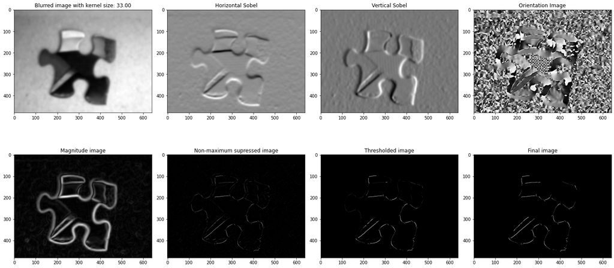

```python
#Question 1.1
def gauss(sigma, truncate = 4):
	kernel_size = 2 * (np.floor(truncate * sigma + 0.5)) + 1
	x, y = np.meshgrid(np.arange(-kernel_size/2,kernel_size/2),np.arange(-kernel_size/2,kernel_size/2))
	d = x*x+y*y
	c = (1/ (2* np.pi*sigma**2))
	g = c * np.exp(-( d / ( 2.0 * sigma**2 ) ) )

	return g, kernel_size

def canny(img, sigma, low_thresh, high_thresh,plot=True):
	g, size = gauss(sigma)
	img= convolve2d(img, g, mode='same', boundary='symm') #applying gaussian filter


	dx = ndimage.sobel(img,axis=0,mode='reflect')
	dy = ndimage.sobel(img,axis=1,mode='reflect')
	angle = np.arctan2(dx, dy)
	angle[angle < 0] += np.pi
	mag = np.hypot(dx,dy)

	z = mag.copy() #intensity gradient of the image

	for row in range(img.shape[0]):
		for col in range(img.shape[1]):
			try:
				if (angle[row][col] >= 0 and angle[row][col] < np.pi/4) or (angle[row][col] - np.pi >= 0 and angle[row][col] - np.pi < np.pi/4):
					# Up and down
					if mag[row - 1][col] > mag[row][col] or mag[row + 1][col] > mag[row][col]:
						z[row][col] = 0

				if (np.pi/4 <= angle[row][col] and angle[row][col] < np.pi/2) or (np.pi/4 <= angle[row][col] - np.pi and angle[row][col] - np.pi < np.pi/2):
					# Up left and down right
					if mag[row - 1][col - 1] > mag[row][col] or mag[row + 1][col + 1] > mag[row][col]:
						z[row][col] = 0

				if (np.pi/2 <= angle[row][col] and angle[row][col] < (3/4)*np.pi) or (np.pi/2 <= angle[row][col] - np.pi and angle[row][col] - np.pi < (3/4)*np.pi):
					# Left and right
					if mag[row][col - 1] > mag[row][col] or mag[row][col + 1] > mag[row][col]:
						z[row][col] = 0

				if ((3/4)*np.pi <= angle[row][col] and angle[row][col] < np.pi) or ((3/4)*np.pi <= angle[row][col] - np.pi and angle[row][col] - np.pi < np.pi):
					# Up right and down left
					if mag[row - 1][col + 1] > mag[row][col] or mag[row + 1][col - 1] > mag[row][col]:
						z[row][col] = 0

			except IndexError as e:
				z[row][col] = 0

	znms = z.copy() #after non-maximum supression

	z[z < low_thresh] = 0
	z[z > high_thresh] = 1

	zthresh = z.copy()# after double thresholding

	change = True
	while change:
		zOld = z.copy()
		for row in range(img.shape[0]):
			for col in range(img.shape[1]):
				try:
					if zOld[row][col] != 0 and zOld[row][col] != 1:
						for r in [-2, -1, 0, 1, 2]:
							for c in [-2, -1, 0, 1, 2]:
								if zOld[row + r][col + c] == 1:
									z[row][col] = 1
				except IndexError as e:
					pass
		change = np.any(z - zOld)

	z[z < 1] = 0 # after hystersis



#Question 1.2
	if not plot:
		return z

	fig, axs = plt.subplots(2, 4, figsize=(20, 10))
	gs1 = plt.GridSpec(2,4)
	gs1.update(wspace=0.0, hspace=0.0) # set the spacing between axes.


	ax = axs.ravel()
	ax[0].imshow(img, cmap='gray')
	ax[0].set_title(f'Blurred image with kernel size: {size:.2f}')

	ax[1].imshow(dx, cmap='gray')
	ax[1].set_title('Horizontal Sobel')

	ax[2].imshow(dy, cmap='gray')
	ax[2].set_title('Vertical Sobel')

	ax[3].imshow(angle, cmap='gray')
	ax[3].set_title('Orientation Image')

	ax[4].imshow(mag, cmap='gray')
	ax[4].set_title('Magnitude image')

	ax[5].imshow(znms, cmap='gray')
	ax[5].set_title('Non-maximum supressed image')

	ax[6].imshow(zthresh, cmap='gray')
	ax[6].set_title('Thresholded image')

	ax[7].imshow(z, cmap='gray')
	ax[7].set_title('Final image')

	fig.tight_layout()

	plt.show()

	return z

z = canny(image_1_grey, 4, 0.1, 0.2)
```

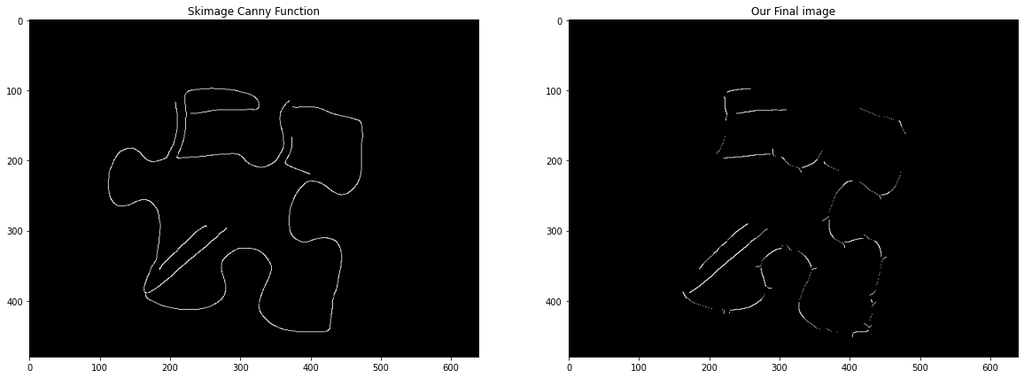

```python
#Question 1.3
fig, axs = plt.subplots(1, 2, figsize=(20, 10))

ax = axs.ravel()
ax[0].imshow(skimage.feature.canny(image_1_grey, 4, 0.1, 0.2, mode='reflect'), cmap='gray')
ax[0].set_title('Skimage Canny Function')

ax[1].imshow(z, cmap='gray')
ax[1].set_title('Our Final image')

plt.show()
```

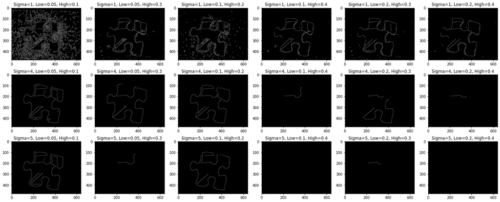

```python
#Question 1.4
sigma_values = [1,4,5]
threshold_value_pairs = [(0.05,0.1),(0.05,0.3),(0.1,0.2),(0.1,0.4),(0.2,0.3),(0.2,0.4)]
fig, axs = plt.subplots(3, 6, figsize=(25, 10))

ax = axs.ravel()
i = 0
for sig in sigma_values:
	for p in threshold_value_pairs:
		ax[i].imshow(skimage.feature.canny(image_1_grey, sig, p[0], p[1], mode='reflect'), cmap='gray')
		ax[i].set_title(F'Sigma={sig}, Low={p[0]}, High={p[1]}')
		i +=1
```

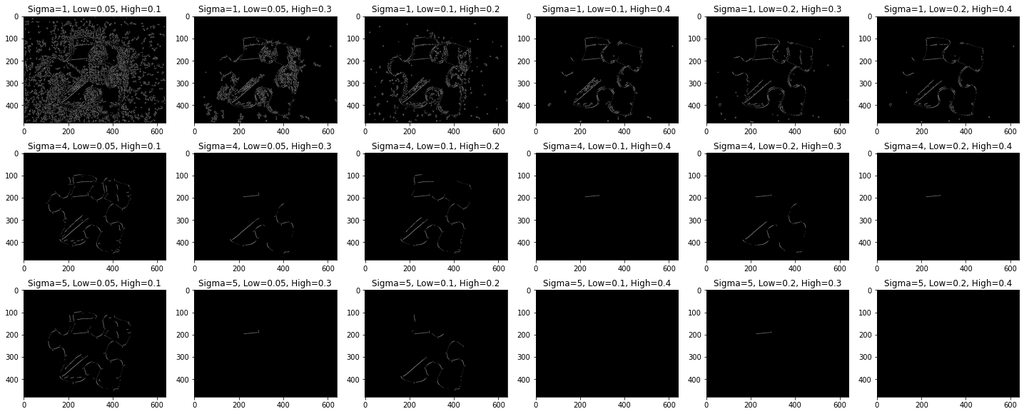

```python
#Question 1.4
sigma_values = [1,4,5]
threshold_value_pairs = [(0.05,0.1),(0.05,0.3),(0.1,0.2),(0.1,0.4),(0.2,0.3),(0.2,0.4)]
fig, axs = plt.subplots(3, 6, figsize=(25, 10))

ax = axs.ravel()
i = 0
for sig in sigma_values:
	for p in threshold_value_pairs:
		ax[i].imshow(canny(image_1_grey, sig, p[0], p[1],plot= False), cmap='gray')
		ax[i].set_title(F'Sigma={sig}, Low={p[0]}, High={p[1]}')
		i +=1
```

Question 1.4 Change in Sigma leads to the image becoming more or less blurred and thus affecting the ability of the alogirthm to discern lines. Change in the thresholds lead to either stricter or more lenient judgement on what counts as an edge or not.

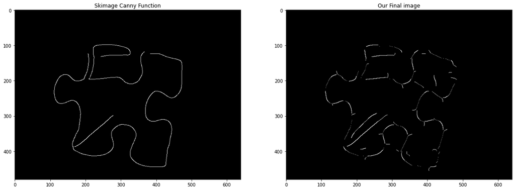

```python
#Question 1.5
fig, axs = plt.subplots(1, 2, figsize=(20, 10))

ax = axs.ravel()
ax[0].imshow(skimage.feature.canny(image_1_grey, 5, 0.1, 0.2, mode='reflect'), cmap='gray')
ax[0].set_title('Skimage Canny Function')

ax[1].imshow(canny(image_1_grey, 6, 0.05, 0.1,plot=False), cmap='gray')
ax[1].set_title('Our Final image')

plt.show()
```

# 2 Harris Corner Detector

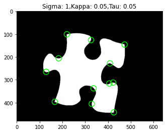

```python
#Question 2.1
def harris(img, sigma=1, kappa=0.05, tau=0.05):

	dx = ndimage.sobel(img,axis=0,mode='constant')
	dy = ndimage.sobel(img,axis=1,mode='constant')
	g, size = gauss(sigma)
	size = int(size)//2
	s = np.zeros((img.shape[0],img.shape[1],3))

	s[:, :, 0] = ndimage.gaussian_filter(dx**2, sigma)
	s[:, :, 1] = ndimage.gaussian_filter(dy**2, sigma)
	s[:, :, 2] = ndimage.gaussian_filter(dx*dy, sigma)


	response = s[:, :, 0] * s[:, :, 1] - s[:, :, 2]**2 - kappa * (s[:, :, 0] + s[:, :, 1])**2


	corners = response.copy()
	for row in range(img.shape[0]):
			for col in range(img.shape[1]):
				try:
					center = response[row][col]
					for r in [-2, -1, 0, 1, 2]:
						for c in [-2, -1, 0, 1, 2]:
							if response[row + r][col + c] > center:
									corners[row][col] = 0
				except IndexError as e:
					pass

	corn = np.where(corners > tau)

	c_img = np.zeros((mask_1.shape[0], mask_1.shape[1], 3))

	c_img[:, :, 0] = mask_1.copy()
	c_img[:, :, 1] = mask_1.copy()
	c_img[:, :, 2] = mask_1.copy()

	for i, j in zip(corn[1], corn[0]):
		c_img = cv2.circle(c_img, (i, j), radius=12, color=(0,1,0), thickness=2)

	plt.imshow(c_img)
	plt.title(f'Sigma: {sigma},Kappa: {kappa},Tau: {tau}')
	plt.show()

harris(image_1_grey)

#Question 2.2
harris(mask_1)
```

[output not shown]

```
Testing Sigma
```

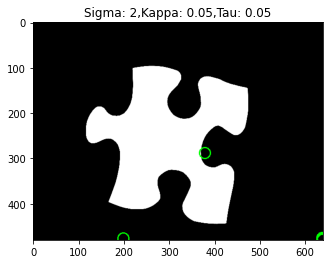

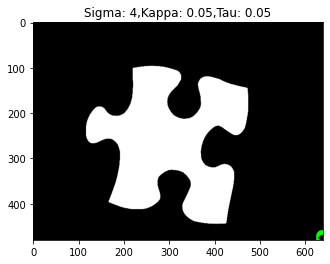

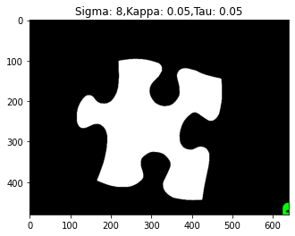

```
Testing Kappa
```

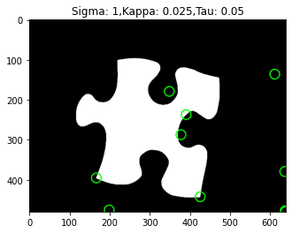

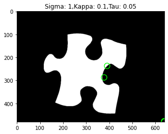

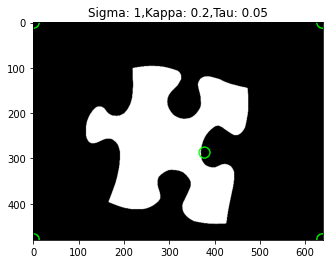

```
Testing Tau
```

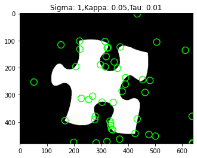

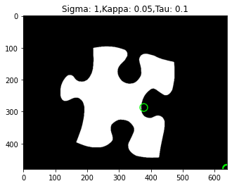

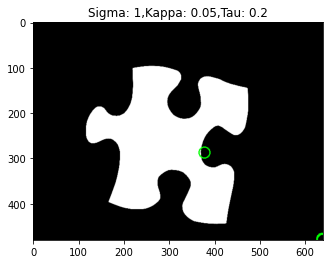

```python
#Question 2.3
print("Testing Sigma")
for sigma in [1,2,4,8]:
    harris(image_1_grey,sigma=sigma)

print("\n\nTesting Kappa")
for kappa in [0.025, 0.05, 0.1, 0.2]:
    harris(image_1_grey,kappa=kappa)

print("\n\nTesting Tau")
for tau in [0.01, 0.05, 0.1, 0.2]:
    harris(image_1_grey,tau=tau)
```

Question 2.4 Perform k-means on the corners detected and select the corner which is at the center of the cluster.

# 3 Histogram of Oriented Gradients Descriptor

```python
image_1 = cv2.resize(image_1, (256, 192))
mask_1 = cv2.resize(mask_1, (256, 192))
```

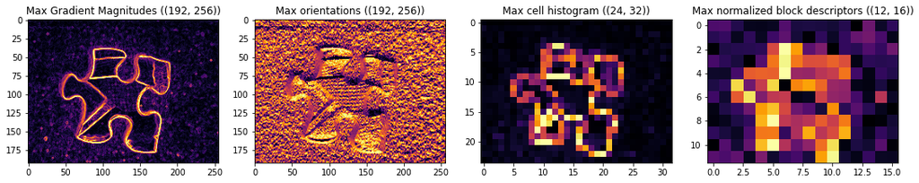

```python
#Question 3.1 and 3.2
def HoG(img, orientations=9, pixels_per_cell=8, cells_per_block=2):

    def stretch(img):
        p2, p98 = np.percentile(img, (2, 98))
        return exposure.rescale_intensity(img, in_range=(p2, p98))

    assert img.shape[0] % pixels_per_cell == 0
    assert img.shape[1] % pixels_per_cell == 0

    assert img.shape[0] >= cells_per_block * pixels_per_cell
    assert img.shape[1] >= cells_per_block * pixels_per_cell

    fig, axs = plt.subplots(1, 4, figsize=(15, 10))
    ax = axs.ravel()

    x = np.array([-1, 0, 1]).reshape(1, 3)
    y = x.transpose()

    dx = np.zeros(img.shape)
    dy = np.zeros(img.shape)
    for c in [0, 1, 2]:
        dx[:, :, c] = convolve2d(img[:, :, c], x, mode='same', boundary='symm')
        dy[:, :, c] = convolve2d(img[:, :, c], y, mode='same', boundary='symm')

    mag_full = np.hypot(dx,dy)

    mag = np.amax(mag_full, axis=2)

    ax[0].imshow(stretch(mag), cmap='inferno')
    ax[0].set_title(f'Max Gradient Magnitudes ({mag.shape})')

    angle_full = np.arctan2(dx, dy)

    angle = np.zeros(mag.shape)


    for x in range(mag_full.shape[0]):
        for y in range(mag_full.shape[1]):
            angle[x, y] = angle_full[x, y, np.argmax(mag_full[x, y])]

    angle[np.where(angle >= np.pi)] = angle[np.where(angle >= np.pi)] - np.pi

    angle[np.where(angle < 0)] = np.abs(angle[np.where(angle < 0)])

    ax[1].imshow(stretch(angle), cmap='inferno')
    ax[1].set_title(f'Max orientations ({angle.shape})')

    bins = [np.pi/orientations * i for i in range(0, orientations)]

    angle_quan = np.digitize(angle, bins=bins, right=False)

    hist = np.zeros((int(angle.shape[0]/pixels_per_cell), int(angle.shape[1]/pixels_per_cell), orientations))


    for cell_x in range(0, int(img.shape[0]/pixels_per_cell)):
        for cell_y in range(0, int(img.shape[1]/pixels_per_cell)):
            for pixel_x in range(int(cell_x * pixels_per_cell), int(cell_x * pixels_per_cell) + pixels_per_cell):
                for pixel_y in range(int(cell_y * pixels_per_cell), int(cell_y * pixels_per_cell) + pixels_per_cell):
                    bin = angle_quan[pixel_x, pixel_y]
                    angle1 = bins[bin - 1]
                    angle2 = bins[bin%9]

                    ratio = (angle[pixel_x, pixel_y] - angle1)/(np.pi / orientations)

                    voting1 = (1 - ratio)*mag[pixel_x, pixel_y]
                    voting2 = ratio*mag[pixel_x, pixel_y]

                    hist[cell_x, cell_y, bin-1] += voting1
                    hist[cell_x, cell_y, bin%9] += voting2


    cell_maxs = np.amax(hist, axis=2)

    ax[2].imshow(stretch(cell_maxs), cmap='inferno')
    ax[2].set_title(f'Max cell histogram ({cell_maxs.shape})')



    blocks_x = (img.shape[0]//pixels_per_cell)//cells_per_block
    blocks_y = (img.shape[1]//pixels_per_cell)//cells_per_block
    hist_blocks = np.zeros((blocks_x, blocks_y, orientations))

    for i, row in enumerate(range(0, img.shape[0]//pixels_per_cell, cells_per_block)):
        for j, col in enumerate(range(0, img.shape[1]//pixels_per_cell, cells_per_block)):
            for o in range(orientations):
                hist_blocks[i, j, o] = np.sum(hist[row:row+cells_per_block, col:col+cells_per_block, :].flatten().reshape(cells_per_block * cells_per_block, 9)[:, o])


    l2 = np.linalg.norm(hist_blocks, 2, axis=2)

    for row in range(hist_blocks.shape[0]):
        for col in range(hist_blocks.shape[1]):
            hist_blocks[row, col, :] /= l2[row, col]

    desc = stretch(np.amax(hist_blocks, axis = 2))

    ax[3].imshow(desc, cmap='inferno')
    ax[3].set_title(f'Max normalized block descriptors ({desc.shape})')


    fig.tight_layout()
    plt.show()

    return hist_blocks.flatten()

hog = HoG(image_1)
```

```python
#Question 3.3
print(f'Final size of image descriptor: {hog.shape[0]}')
```

```
Final size of image descriptor: 1728
```

Question 3.4

- Training samples: Mask images to tune hyperparameters.
- Resize the images to ensure that the width and height of the image in pixels is a multiple of pixels per cell, and that the width and height are at least (cells per block * pixels per cell pixels) in size.
- We would break up larger images and detect puzzle pieces at different scales using an image pyramid to scan through the image.
- Once the HoG descriptor has been generated, clustering techniques could be performed to segment edge/non-edge or puzzle/non-puzzle regions using the descriptors as the data.

Question 3.5

- The HoG is a good method for detecting puzzle pieces in the previous question as it provides the puzzle piece with a very different intensity to that of the bacground making it suitable for thresholding. It also identifies lines precisely as it takes the gradient filters.

Question 4

A combination of these techniques would most likely lead to the best results in Tino's puzzle-solving system, as the combination can help to reduce the impact of erroneous results from any single algorithm. All of the algorithms will have some inherent innacuracy which may lead to unsolveable systems if some peices are not detected correctly.